# Konsep_dasar_Python slides

**ALGORITMA DAN PEMROGRAMAN**

*Modul Algoritma*

*Tim Pengajar: I Gede Yudi Paramartha, Bakhtiar Amaludin, Widya Ari Pranayoga*

**APA ITU ALGORITMA ?**

**Muhammad ibn Musa al-Khwarizmi** memperkenalkan kata algoritma saat menjelaskan sebuah metode untuk menyelesaikan persamaan linear dan kuadratik.

Misalnya, kita ingin membuat sebuah algoritma untuk membuat secangkir teh.

1. Siapkan air dan panci.
2. Letakkan panci di atas kompor.
3. Isi panci dengan air.
4. Nyalakan kompor dan tunggu hingga air mendidih.
5. Matikan kompor.
6. Siapkan cangkir dan kantong teh.
7. Letakkan kantong teh di dalam cangkir.
8. Tuang air panas ke dalam cangkir.
9. Tunggu beberapa menit hingga teh meresap ke dalam air.
10. Angkat kantong teh dari cangkir.
11. Secangkir teh siap disajikan.

Algoritma didefinisikan sebagai serangkaian **instruksi step-by-step** untuk menyelesaikan suatu masalah atau melakukan tugas tertentu.

[figure not shown]

**JENIS-JENIS ALGORITMA**

**Sorting Algoritms**

*Bubble sort, selection sort, insertion sort, quick sort, dan merge sort*

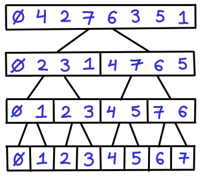

```python
angka_acak = [8, 2, 6, 4, 5]
sorted(angka_acak)
```

```
[2, 4, 5, 6, 8]
```

```python
negara_ASEAN = ['Indonesia', 'Brunei', 'Malaysia', 'Thailand']
sorted(negara_ASEAN)
```

```
['Brunei', 'Indonesia', 'Malaysia', 'Thailand']
```

```python
angka_acak = [8.5, 2.9, 6.2, 4.7, 5]
sorted(angka_acak, reverse=True)
```

```
[8.5, 6.2, 5, 4.7, 2.9]
```

**Shortest-path Algorithms**

*Dijkstra's algorithm, Bellman-Ford algorithm, A' algorithm, dan Floyd-Warshall algorithm.*

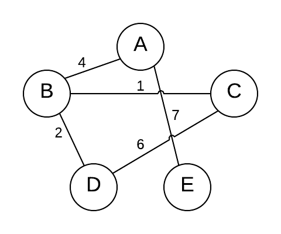

**Searching Algorithms**

*Linear search, binary search, interpolation search, depth-first search, dan breadth-first search.*

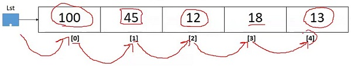

**KOMPLEKSITAS ALGORITMA**

**Big O Notations**

Kompleksitas waktu atau ruang diukur dalam relasi dengan ukuran input data.

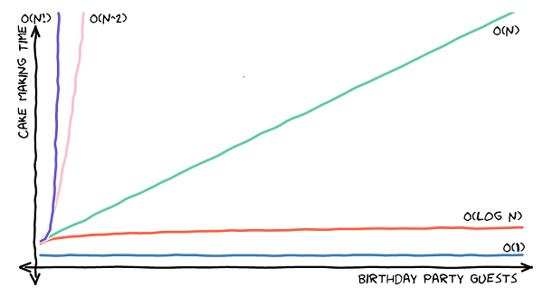

sumber: https://www.freecodecamp.org/news/big-o-notation/

**PYTHON STATEMENTS**

Sebuah **kode atau perintah** yang kita jalankan di bahasa pemrograman python.

Python statement diakhiri dengan karakter NEWLINE, artinya setiap line di Python script adalah statement.

*Single statement on multiple lines*

```python
total = 1 + \
        2 + \
        3

print(total)
```

```
6
```

*Multi statements on single line*

```python
x = 'satu'; y = 'dua'

print(x)
```

```
satu
```

**SYNTAX DASAR PYTHON**

*Syntax adalah aturan-aturan yang digunakan untuk menulis instruksi dalam bahasa pemrograman.*

Jika syntax salah maka akan mengakibatkan notifikasi *Syntax Error*

**Python Identifiers**

Identifier dimulai dengan huruf A sampai Z atau a sampai z atau garis bawah (_) diikuti dengan nol atau lebih huruf, garis bawah dan angka (0 sampai 9).

Python tidak mengizinkan karakter tanda baca seperti @, $, dan % atau tanda spasi (white space) di dalam identifier.

*contoh identifiers*

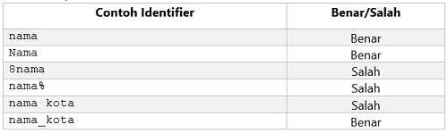

**Indentansi**

Python menggunakan indentasi untuk menandai sebuah blok kode.

*contoh penulisan indentansi*

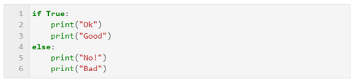

*salah penulisan indentansi, muncul notifikasi error*

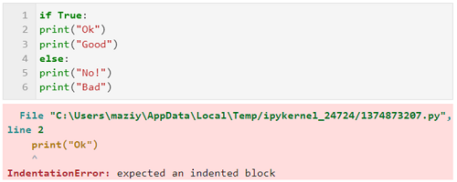

**Komentar**

Komentar digunakan untuk membantu mendokumentasikan alur kode yang dibuat sehingga lebih mudah dipahami. Biasanya merupakan kalimat penjelas atas alur kode tersebut.

*contoh komentar*

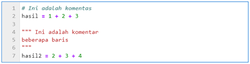

**Kuotasi Teks**

Untuk menandai data dalam bentuk teks atau strings, Python menggunakan tanda petik ' atau ". Kita juga bisa menggunakan tanda petik ganda tiga kali, jika teks yang kita definisikan terdiri dari beberapa baris.

*contoh kuotasi teks*

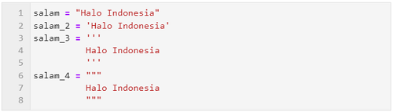

**TERIMA KASIH**

*Kelas dilanjutkan dengan penugasan terstruktur.*